# Data Exploration - progetto numero uno

2022-11-28

### Some sort of intorduction

```bash
curl https://en.wikipedia.org/wiki/List_of_films_based_on_Marvel_Comics_publications -o marvel_wiki.html
```

```
##   % Total    % Received % Xferd  Average Speed   Time    Time     Time  Current
##                                  Dload  Upload   Total   Spent    Left  Speed
##
  0     0    0     0    0     0      0      0 --:--:-- --:--:-- --:--:--     0
100  469k  100  469k    0     0   648k      0 --:--:-- --:--:-- --:--:--  651k
```

```r
p <- read_html("marvel_wiki.html")
tables <- p %>% html_nodes(".wikitable")
summary(tables)
```

```
##       Length Class    Mode
##  [1,] 2      xml_node list
##  [2,] 2      xml_node list
##  [3,] 2      xml_node list
##  [4,] 2      xml_node list
##  [5,] 2      xml_node list
##  [6,] 2      xml_node list
##  [7,] 2      xml_node list
##  [8,] 2      xml_node list
##  [9,] 2      xml_node list
## [10,] 2      xml_node list
## [11,] 2      xml_node list
## [12,] 2      xml_node list
## [13,] 2      xml_node list
## [14,] 2      xml_node list
## [15,] 2      xml_node list
## [16,] 2      xml_node list
## [17,] 2      xml_node list
## [18,] 2      xml_node list
```

### Scraping Wikipedia

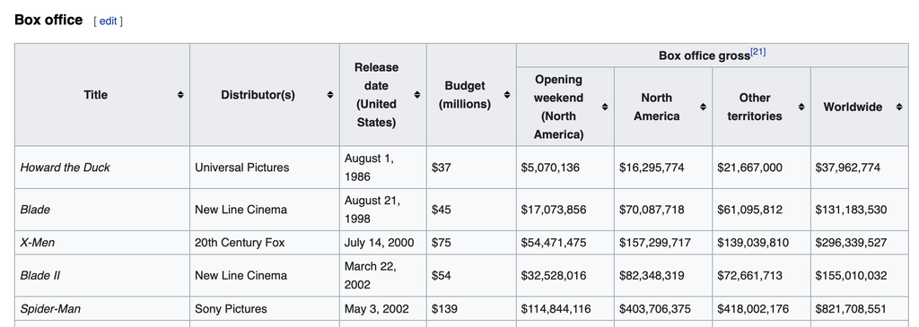

Xpaths of interesting tables with data:

`//*[@id="mw-content-text"]/div[1]/table[1]` : Feature films  
`//*[@id="mw-content-text"]/div[1]/table[15]` : Box office  
`//*[@id="mw-content-text"]/div[1]/table[16]` : Critical and public responce  
Read as a data frame and skip the first row as the tables have two-level headers.

```r
box_office <- tables[15] %>% html_table() %>% as.data.frame() %>% tibble() %>% filter(!row_number() %in% c(1))
reviews <- tables[16] %>% html_table() %>% as.data.frame() %>% tibble() %>% filter(row_number() != 1)
```

Additionally remove the last two rows, they contains taotal and average values.

```r
box_office <- head(box_office, -2)
```

Overwrite column names.

```r
colnames(box_office) <- c("title",
    "distributor", "release_date", "budget",
    "box_office_opening_weekend_us", "box_office_us", "box_office_other",
    "box_office_worldwide")

colnames(reviews) <- c("title",
    "rotten_tomatoes", "metacritic", "cinemascore")
```

### Clean the data

In order to convert string values of money into integers, we need to clean it up from all dollar signs and commas. PS. There might be a better way to achive this, but I didn’t find it.

```r
box_office$budget <- str_remove_all(box_office$budget, "\\$")
box_office$box_office_opening_weekend_us <- str_remove_all(box_office$box_office_opening_weekend_us, "\\$")
box_office$box_office_us <- str_remove_all(box_office$box_office_us, "\\$")
box_office$box_office_other <- str_remove_all(box_office$box_office_other, "\\$")
box_office$box_office_worldwide <- str_remove_all(box_office$box_office_worldwide, "\\$")

box_office$budget <- str_remove_all(box_office$budget, ",")
box_office$box_office_opening_weekend_us <- str_remove_all(box_office$box_office_opening_weekend_us, ",")
box_office$box_office_us <- str_remove_all(box_office$box_office_us, ",")
box_office$box_office_other <- str_remove_all(box_office$box_office_other, ",")
box_office$box_office_worldwide <- str_remove_all(box_office$box_office_worldwide, ",")
```

In the case of reviews we need to parse the string values in column. It contains information about the socre itself and the amount of reviews.

```r
reviews$rotten_tomatoes_score <-
    sapply(str_extract_all(reviews$rotten_tomatoes, "\\d+"), "[", 1)
reviews$rotten_tomatoes_num_reviews <-
    sapply(str_extract_all(reviews$rotten_tomatoes, "\\d+"), "[", 2)
reviews$metacritic_score <-
    sapply(str_extract_all(reviews$metacritic, "\\d+"), "[", 1)
reviews$metacritic_num_reviews <-
    sapply(str_extract_all(reviews$metacritic, "\\d+"), "[", 2)
```

Now its time for column type convertion

```r
box_office$release_date <- as.Date(box_office$release_date, "%B %d, %Y")

box_office <- box_office %>% mutate(across(c("budget",
    "box_office_opening_weekend_us", "box_office_us", "box_office_other",
    "box_office_worldwide"), as.numeric))
reviews <- reviews %>% mutate(across(c("rotten_tomatoes_score",
    "rotten_tomatoes_num_reviews", "metacritic_score"), as.numeric))
```

Fix some missing data: Morbius has a string parsing error, hardcoded data

```r
box_office <- box_office %>% mutate(budget = replace(budget, title == "Morbius", 79))
```

Inhumans has NAN, so populate with a trimmed average

```r
budget_avg <- mean(box_office$budget, na.rm = TRUE, trim = 0.1) %>% round()
box_office <- box_office %>% mutate(budget = replace(budget, title == "Inhumans", budget_avg))
```

Fixing film titles in order to merge both tables

```r
reviews <- reviews %>% mutate(title = replace(title, title == "Marvel's The Avengers", "The Avengers"))
reviews <- reviews %>% mutate(title = replace(title, title == "The Punisher (2004)", "The Punisher"))
box_office <- box_office %>% mutate(title =
              replace(title,
                      title == "Fantastic Four" & release_date == "2005-07-08",
                      "Fantastic Four (2005)"))
box_office <- box_office %>% mutate(title =
              replace(title,
                      title == "Fantastic Four" & release_date == "2015-08-07",
                      "Fantastic Four (2015)"))
```

Also `budget` column is in $ millions, so we need to change it to fit the rest.

```r
box_office <- box_office %>% mutate(budget = budget * 1e+6)
```

Glue everything together.

```r
data <- box_office %>% inner_join(reviews, by = "title")
```

### LETSDRAW

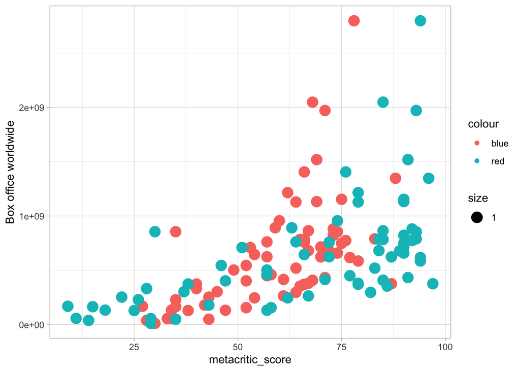

```r
g <- data %>% ggplot(aes(size = 1)) +
    geom_point(aes(x = metacritic_score, y = box_office_worldwide,
                    colour = "blue")) +
    geom_point(aes(x = rotten_tomatoes_score, y = box_office_worldwide,
                colour = "red")) +
    ylab("Box office worldwide") + theme_light()

show(g)
```

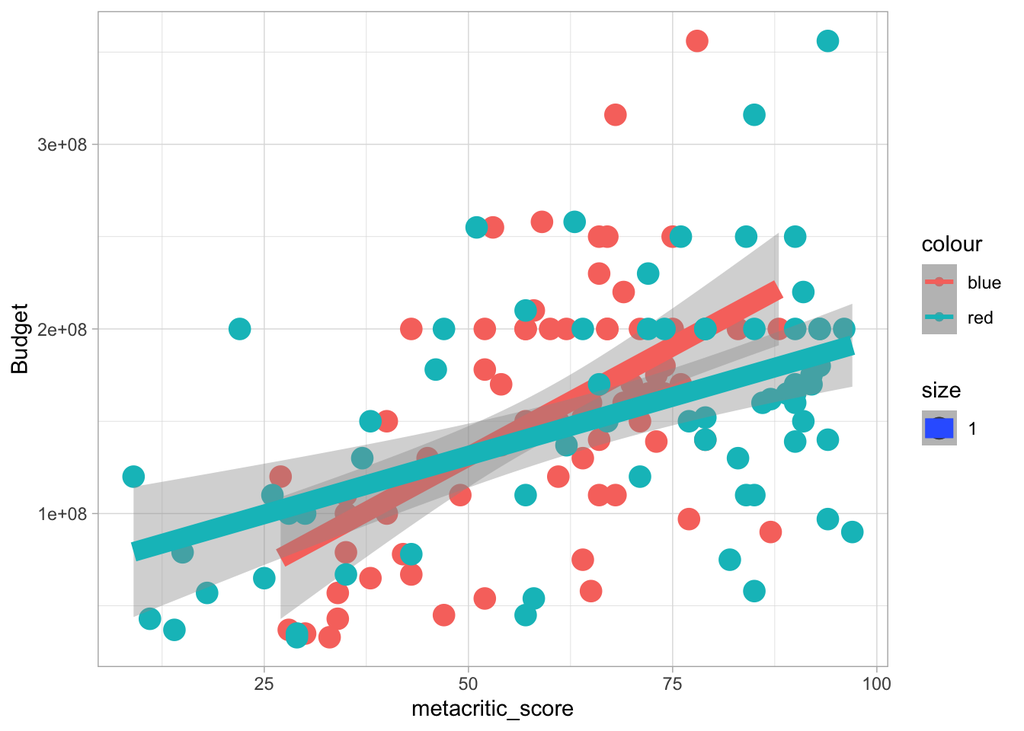

```r
g <- data %>% ggplot(aes(size = 1)) +
    geom_point(aes(x = metacritic_score, y = budget,
                    colour = "blue")) +
    geom_smooth(aes(x = metacritic_score, y = budget, colour = "blue"),
                    method = lm, formula = y ~ x) +
    geom_point(aes(x = rotten_tomatoes_score, y = budget,
                colour = "red")) +
    geom_smooth(aes(x = rotten_tomatoes_score, y = budget, colour = "red"),
                    method = lm, formula = y ~ x) +
     ylab("Budget") + theme_light()

show(g)
```